# Project: CO2, Carbon Dioxide Uptake in Grass Plants

Carayon - Taillieu

02/10/2020

## Description of the dataset

The CO2 data frame is the result of an experiment based on the cold tolerance of the grass species Echinochloa crus-galli. We load the data and get some information about it thanks to this commands:

```r
data("CO2")
dim(CO2)
```

```
## [1] 84  5
```

```r
names(CO2)
```

```
## [1] "Plant"     "Type"      "Treatment" "conc"      "uptake"
```

The CO2 uptake of six plants from Quebec and six plants from Mississippi was measured at several levels of ambient CO2 concentration. Half the plants of each type were chilled overnight before the experiment was conducted.

## Data exploration

### Summary

Let’s see the dataset and its structure:

```r
CO2
```

```
##    Plant        Type  Treatment conc uptake
## 1    Qn1      Quebec nonchilled   95   16.0
## 2    Qn1      Quebec nonchilled  175   30.4
## 3    Qn1      Quebec nonchilled  250   34.8
## 4    Qn1      Quebec nonchilled  350   37.2
## 5    Qn1      Quebec nonchilled  500   35.3
## 6    Qn1      Quebec nonchilled  675   39.2
## 7    Qn1      Quebec nonchilled 1000   39.7
## 8    Qn2      Quebec nonchilled   95   13.6
## 9    Qn2      Quebec nonchilled  175   27.3
## 10   Qn2      Quebec nonchilled  250   37.1
## 11   Qn2      Quebec nonchilled  350   41.8
## 12   Qn2      Quebec nonchilled  500   40.6
## 13   Qn2      Quebec nonchilled  675   41.4
## 14   Qn2      Quebec nonchilled 1000   44.3
```

[output cut: 70 more lines]

```r
class(CO2) # explain what it is?
```

```
## [1] "nfnGroupedData" "nfGroupedData"  "groupedData"    "data.frame"
```

```r
str(CO2)
```

```
## Classes 'nfnGroupedData', 'nfGroupedData', 'groupedData' and 'data.frame':   84 obs. of  5 variables:
##  $ Plant    : Ord.factor w/ 12 levels "Qn1"<"Qn2"<"Qn3"<..: 1 1 1 1 1 1 1 2 2 2 ...
##  $ Type     : Factor w/ 2 levels "Quebec","Mississippi": 1 1 1 1 1 1 1 1 1 1 ...
##  $ Treatment: Factor w/ 2 levels "nonchilled","chilled": 1 1 1 1 1 1 1 1 1 1 ...
##  $ conc     : num  95 175 250 350 500 675 1000 95 175 250 ...
##  $ uptake   : num  16 30.4 34.8 37.2 35.3 39.2 39.7 13.6 27.3 37.1 ...
##  - attr(*, "formula")=Class 'formula'  language uptake ~ conc | Plant
##   .. ..- attr(*, ".Environment")=<environment: R_EmptyEnv>
##  - attr(*, "outer")=Class 'formula'  language ~Treatment * Type
##   .. ..- attr(*, ".Environment")=<environment: R_EmptyEnv>
##  - attr(*, "labels")=List of 2
##   ..$ x: chr "Ambient carbon dioxide concentration"
##   ..$ y: chr "CO2 uptake rate"
##  - attr(*, "units")=List of 2
##   ..$ x: chr "(uL/L)"
##   ..$ y: chr "(umol/m^2 s)"
```

The output confirms what we have seen before thanks to the functions and help section.

```r
summary(CO2)
```

```
##      Plant             Type         Treatment       conc          uptake
##  Qn1    : 7   Quebec     :42   nonchilled:42   Min.   :  95   Min.   : 7.70
##  Qn2    : 7   Mississippi:42   chilled   :42   1st Qu.: 175   1st Qu.:17.90
##  Qn3    : 7                                    Median : 350   Median :28.30
##  Qc1    : 7                                    Mean   : 435   Mean   :27.21
##  Qc3    : 7                                    3rd Qu.: 675   3rd Qu.:37.12
##  Qc2    : 7                                    Max.   :1000   Max.   :45.50
##  (Other):42
```

```r
levels(CO2 $Plant)
```

```
##  [1] "Qn1" "Qn2" "Qn3" "Qc1" "Qc3" "Qc2" "Mn3" "Mn2" "Mn1" "Mc2" "Mc3" "Mc1"
```

Thanks to the summary, we obtain the different information depending on the column names, we do the levels function to the plant as we don’t have all the information displayed in the summary. We deduce that we put 12 plants in several conditions (with their name corresponding to the treatment and type and number) and measures the concentration of ambient carbon dioxide and the carbon dioxide uptake rates. We can see that the concentration of carbon dioxide as the carbon dioxide uptake rates for all plants.

By comparing the types of plants (Quebec - Mississipi),we can see some characteristics:

```r
tapply(CO2 $uptake, CO2 $Type, summary)
```

```
## $Quebec
##    Min. 1st Qu.  Median    Mean 3rd Qu.    Max.
##    9.30   30.32   37.15   33.54   40.15   45.50
##
## $Mississippi
##    Min. 1st Qu.  Median    Mean 3rd Qu.    Max.
##    7.70   13.88   19.30   20.88   28.05   35.50
```

Plants from Quebec have an uptake rate between 9.30 and 45.50 whereas for Mississippi, it is between 7.70 and 35.50. Moreover, for Quebec, half of plants have an uptake rate more than 37.15 while for Mississippi, it is less than 19.30. There are huge differences between Quebec and Mississippi minimums, maximums, medians and also quartiles. 25% of Quebec plants have an uptake rate under 30.32 while for Mississipi it is 13.88. Finally, for 75% of Mississippi plants, the uptake rate is less than 28.05 whereas for Quebec it is less than 40.15.

So it appears that Quebec plants seem to have more important uptake rate than Mississippi plants.

Let’s take a look on two plants from Quebec, one chilled and one non chilled:

```r
tapply(CO2 $uptake, CO2 $Plant, summary)
```

```
## $Qn1
##    Min. 1st Qu.  Median    Mean 3rd Qu.    Max.
##   16.00   32.60   35.30   33.23   38.20   39.70
##
## $Qn2
##    Min. 1st Qu.  Median    Mean 3rd Qu.    Max.
##   13.60   32.20   40.60   35.16   41.60   44.30
##
## $Qn3
##    Min. 1st Qu.  Median    Mean 3rd Qu.    Max.
##   16.20   36.35   42.10   37.61   43.40   45.50
##
## $Qc1
##    Min. 1st Qu.  Median    Mean 3rd Qu.    Max.
##   14.20   27.20   32.50   29.97   35.00   38.70
##
## $Qc3
##    Min. 1st Qu.  Median    Mean 3rd Qu.    Max.
##   15.10   27.50   38.10   32.59   39.25   41.40
##
## $Qc2
##    Min. 1st Qu.  Median    Mean 3rd Qu.    Max.
##    9.30   31.15   37.50   32.70   38.70   42.40
##
## $Mn3
##    Min. 1st Qu.  Median    Mean 3rd Qu.    Max.
##   11.30   22.60   27.80   24.11   28.00   28.50
##
## $Mn2
##    Min. 1st Qu.  Median    Mean 3rd Qu.    Max.
##   12.00   26.30   31.10   27.34   31.65   32.40
##
## $Mn1
##    Min. 1st Qu.  Median    Mean 3rd Qu.    Max.
##   10.60   22.70   30.00   26.40   31.65   35.50
##
## $Mc2
##    Min. 1st Qu.  Median    Mean 3rd Qu.    Max.
##    7.70   11.85   12.50   12.14   13.35   14.40
##
## $Mc3
##    Min. 1st Qu.  Median    Mean 3rd Qu.    Max.
##   10.60   17.90   17.90   17.30   18.45   19.90
##
## $Mc1
##    Min. 1st Qu.  Median    Mean 3rd Qu.    Max.
##    10.5    16.5    18.9    18.0    20.7    22.2
```

So we see that for two plants of number 3 from the same origin (Quebec) but one chilled and one non chilled, we obtain huge differences of uptake rate.

We can study it in depth using summarize function from the dplyr library.

```r
library(dplyr)
summarize(group_by(CO2, Type), average_uptake = mean(uptake))
```

```
## # A tibble: 2 x 2
##   Type        average_uptake
##   <fct>                <dbl>
## 1 Quebec                33.5
## 2 Mississippi           20.9
```

```r
summarize(group_by(CO2, Treatment), average_uptake = mean(uptake))
```

```
## # A tibble: 2 x 2
##   Treatment  average_uptake
##   <fct>               <dbl>
## 1 nonchilled           30.6
## 2 chilled              23.8
```

```r
summarize(group_by(CO2, conc), average_uptake = mean(uptake))
```

```
## # A tibble: 7 x 2
##    conc average_uptake
##   <dbl>          <dbl>
## 1    95           12.3
## 2   175           22.3
## 3   250           28.9
## 4   350           30.7
## 5   500           30.9
## 6   675           32.0
## 7  1000           33.6
```

From these results, we can observe that the average uptake for plants from Quebec is higher than the one for plants from Mississippi (33.5 and 20.9 umol/m^2 sec respectively). If we compare them according to the treatment, chilled plants have a smaller average uptake compared to nonchilled ones (23.8 as opposed to 30.6 umol/m^2 sec). Finally, it makes sense to see that when we increase the concentration of ambient carbon dioxide, the plants tend to have better carbon dioxide uptake rates.

## Data visualization

### boxplot uptake fonction country

Using different plots, we will visualize our data based on what we saw before.

Firstly, we can take a look on our plant types (Quebec and Mississippi) and link them with the uptake rate using boxplots:

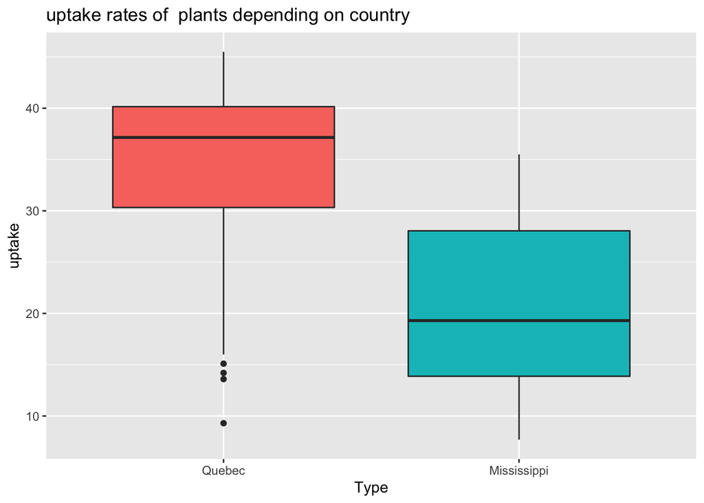

```r
library(ggplot2)
ggplot(subset(CO2), aes(x=Type, y=uptake,  fill=Type)) + geom_boxplot(show.legend = FALSE) + ggtitle("uptake rates of  plants depending on country")
```

```r
#boxplot(uptake ~ Type, data = CO2,boxwex = 0.5, col = c("orange", "yellow"),main = "Uptake rates of plants depending on country",xlab = "country",ylab = "uptake")
```

Now, let’s take a look on the importance of the treatment on those plants. Let’s compare the uptake rate depending on the treatment of plants. * For Quebec

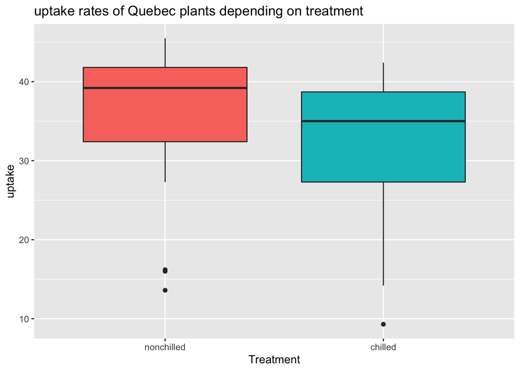

```r
library(ggplot2)
#ggplot(subset(CO2, Type == "Quebec"), aes(x=Treatment, y=uptake, fill=Plant)) +
 # geom_boxplot() + ggtitle("uptake rates of Quebec plants depending on treatment")

ggplot(subset(CO2, Type == "Quebec"), aes(x=Treatment, y=uptake, fill = Treatment)) + geom_boxplot(show.legend = FALSE) + ggtitle("uptake rates of Quebec plants depending on treatment")
```

In the previous part, we study two plants from Quebec with different treatments and find out that there were important differences in their uptake rates. It appears clearly here as less than 75% of chilled plants are under 39 while half of nonchilled have an uptake rate of more than 39.

- For Mississippi

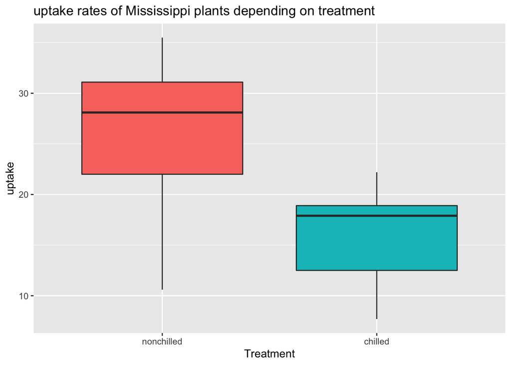

```r
#ggplot(subset(CO2, Type == "Mississippi"), aes(x=Treatment, y=uptake, fill=Plant)) #+geom_boxplot()  +  ggtitle("uptake rates of Mississippi plants depending on #treatment")

ggplot(subset(CO2, Type == "Mississippi"), aes(x=Treatment, y=uptake, fill= Treatment)) +geom_boxplot(show.legend = FALSE)  +  ggtitle("uptake rates of Mississippi plants depending on treatment")
```

Now, if we combine our plots, we will obtain the following result:

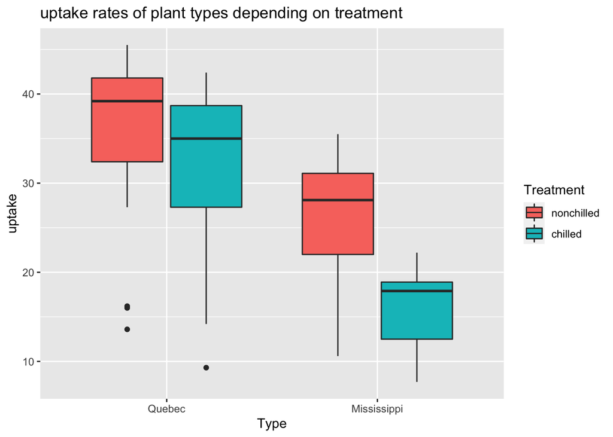

```r
p<-ggplot(CO2, aes(x=Type, y=uptake, fill=Treatment)) +
  geom_boxplot() + ggtitle("uptake rates of plant types depending on treatment")
p + scale_color_brewer(palette="Set1")
```

Thanks to those boxplots, we can clearly see that depending on the type of plants and the treatment, there are some chance to obtain very different uptake rates.

```r
#IDEEE RAJOUTER ???
#If we split our boxplots depending the number of the plant, we will then obtain:
#library(ggplot2)
#p<-ggplot(CO2, aes(x=Plant, y=uptake, fill=Treatment, color=Type)) +
 # geom_boxplot() + ggtitle("uptake rates of plants depending on treatment")
#p + scale_color_brewer(palette="Set1")
```

### Qplot

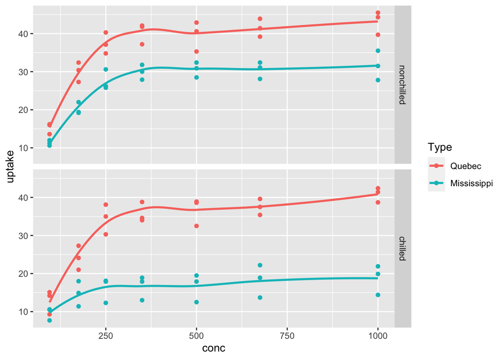

```r
library(ggplot2)
qplot(conc, uptake, facets = Treatment ~ ., data = CO2,
      color = Type, geom = c("point", "smooth"), se = FALSE)
```

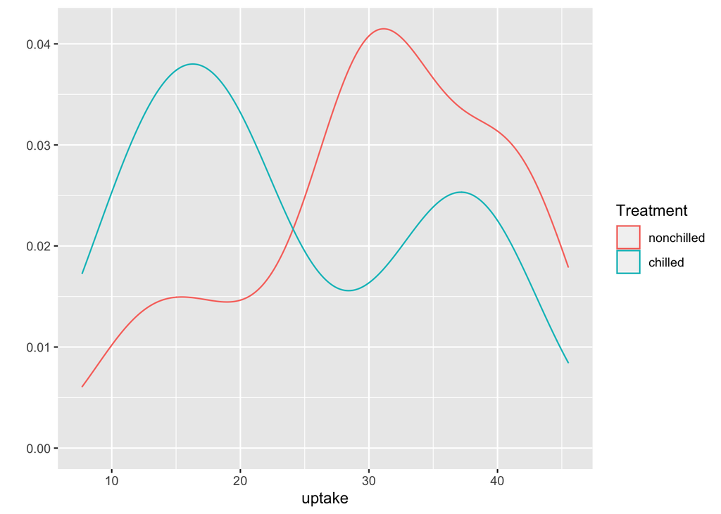

```r
qplot(uptake, data = CO2, color = Treatment, geom = "density")
```

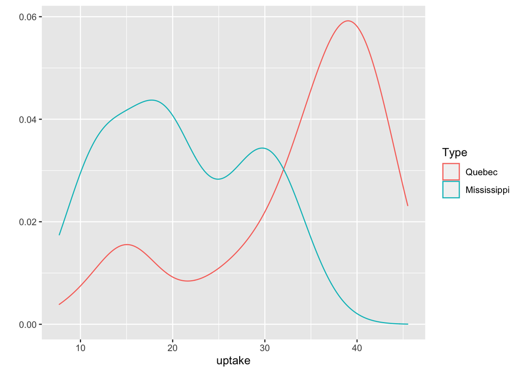

```r
qplot(uptake, data = CO2, color = Type, geom = "density")
```